# Simulating Dataset

Stuart Lacy

28 April 2016

# 1 Introduction

The aim of this script is to be used as a notepad for building a simulated registry dataset.

# 2 `weisim`

This code will use the `weisum` function found in the included `rfun.R` file that Simon provided.

```r
library(dplyr)
library(flexsurv)
```

```r
library(survival)
library(knitr)
library(ggplot2)
source('../tinkerings/rfun.R')
opts_chunk$set(error=T, fig.align='center')
```

Here’s a function call with the default arguments:

```r
set.seed(17)
head(weisim(n=100, p=1, b=1, shp=1, rancens=T, rate=1, trunc=F, tau=2))
```

```
## 47 percent censored
```

```
##          time cens          x
## 1 0.001773913    0 -1.0150087
## 2 0.003056026    1  1.6735260
## 3 0.008381956    1  0.8384711
## 4 0.008385771    0 -0.3434788
## 5 0.015988125    1  0.7720908
## 6 0.023657099    1  0.6338803
```

```r
head(weisim(n=100, p=2, b=c(0.3, 2), shp=1, rancens=T, rate=1, trunc=F, tau=2))
```

```
## 56 percent censored
```

```
##           time cens         X1        X2
## 1 0.0001983379    1  1.8467924  3.091732
## 2 0.0019733437    1  2.2636966  1.046642
## 3 0.0025742831    1  1.2775330  1.361635
## 4 0.0029171893    1  1.3669155  1.969414
## 5 0.0032285662    1  0.5422631  1.353716
## 6 0.0047850458    1 -0.4773234 -1.128403
```

Let’s try and understand what each mean:

- `n` (int): Number of samples to make
- `p` (int): Number of parameters
- `b` (double): Coefficients, a vector with length `p`
- `shp` (double): Shape
- `rancens` (bool): Whether to use random censoring
- `rate` (double): Random censoring rate
- `trunc` (bool): Not entirely sure, whether to truncate data?
- `tau` (double): Parameter involved in truncation

# 3 `weisim2`

I’ve refactored `weisim` to allow for co-variates with normal distributions with means and variances different to 0 and 1 (the defaults which are used in `weisim`).

The argument list is now:

- `n` (int): Number of samples to make
- `beta` (double): Coefficients, a vector with length `p`
- `mu` (double): Means of the covarites, a vector with length `p`
- `sigma` (double): Standard deviations of the covarites, a vector with length `p`
- `shape` (double): Shape
- `rancens` (bool): Whether to use random censoring
- `rate` (double): Random censoring rate
- `trunc` (bool): Not entirely sure, whether to truncate data?
- `tau` (double): Parameter involved in truncation

I’ve also changed the calculation of event time, so that it’s just *-log(u)* which is raised to *1/p*, whereas before it was the whole *-log(u) / exp(betaX)* which was raised to this power. Furthermore I’ve used scale as 1 / scale. This difference is resulting from a different parameterisation of S(t) from a Weibull distribution, I used the one that I’ve seen in other publications and Wikipedia, while the version used by the original authors of `rfun` is that used in the *Klein & Moeschberger* book.

**NB: `p` is no longer an argument to this function, instead it is implicitly derived as the length of `beta`, `mu`, and `sigma`.**

```r
weisim2(10, beta=c(1.5, 0.7), mu=c(0, 5), sigma=c(1.3, 2), shape=0.8, rate=1.5)
```

```
## 90 percent censored
```

```
##    time status         X1       X2
## 1     0      0  2.5301184 7.069394
## 2     0      0  2.1208238 3.734119
## 3     1      1  0.8096002 4.422801
## 4     1      0  1.4541907 7.689022
## 5     1      0 -0.2175811 6.945752
## 6     1      0  0.6549798 2.824351
## 7     1      0 -0.3105305 4.868624
## 8     1      0 -0.2779225 3.566095
## 9     2      0  5.1216692 5.823776
## 10    2      0  0.9687163 3.745263
```

So this works, and it quits if the user doesn’t provide enough information.

```r
weisim2(10, beta=c(1.5), mu=c(0, 5), sigma=c(1.3, 2), shape=0.8, rate=1.5)
```

```
## Error in weisim2(10, beta = c(1.5), mu = c(0, 5), sigma = c(1.3, 2), shape = 0.8, : Error: Number of betas must be equal to length of mu + pbinomial
```

# 4 Simulating survival times

Let’s see if we can use this function to simulate survival times drawn from the distribution of events in the registry data.

```r
registry_data <- readRDS("../data/registry_data.rds")
```

## 4.1 Null model

I’ll start with the null model:

```r
nullmod <- flexsurv::flexsurvreg(Surv(stime, status) ~ 1, data=registry_data, dist='weibull')
nullmod
```

```
## Call:
## flexsurv::flexsurvreg(formula = Surv(stime, status) ~ 1, data = registry_data,
##     dist = "weibull")
##
## Estimates:
##        est       L95%      U95%      se
## shape  6.53e-01  6.25e-01  6.83e-01  1.47e-02
## scale  1.19e+03  1.10e+03  1.30e+03  5.07e+01
##
## N = 1784,  Events: 1296,  Censored: 488
## Total time at risk: 1631885
## Log-likelihood = -10327.78, df = 2
## AIC = 20659.56
```

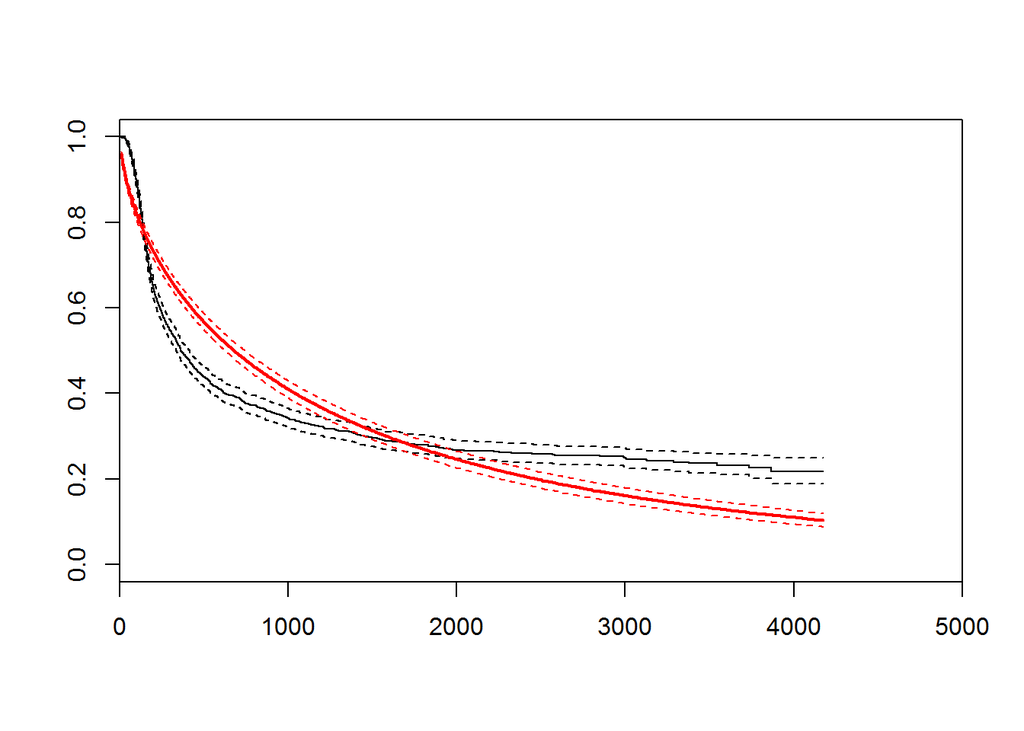

```r
plot(nullmod, xlim=c(0, 5000))
```

Let’s try and generate some meaningful event times then, using ‘sensible’ values for these parameters, remembering that the values for shape and scale shown here are *exponents* of the coefficients, which is fine for `scale` since this will be exponentiated when calculating the linear predictor, but for `shape` which isn’t exponentiated during the calculation, we need to do this manually.

I’ll firstly try without any covariates, just the intercept (which is scale). Since scale is going to be exponentiated later on, it needs to be supplied in the log transform. I’m unsure with shape whether to make it 1/shape, or keep it the same as it is, which is consistent with `pweibull`. I’ll try with just shape, particularly as the function itself uses 1/shape in its calculation.

```r
nullest = weisim2(10000, beta=NULL, mu=NULL, sigma=NULL, scale=log(1190), shape=0.653, rancens=F, rate=0.5, trunc=F)
```

```
## 0 percent censored
```

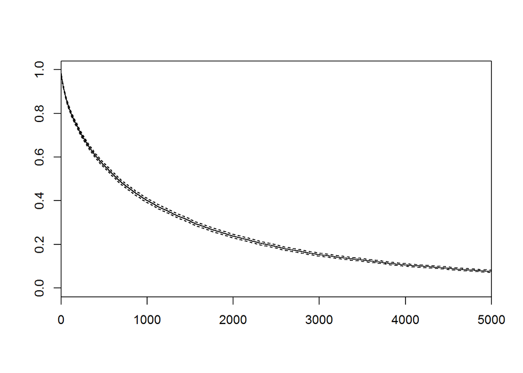

```r
plot(survfit(Surv(time, status) ~ 1, data=nullest), xlim=c(0, 5000))
```

That looks right!

Let’s see if this function produces similar values to that provided by `rweibull`:

**NB: For rweibull we pass in the exponentiated parameters, for the sim function we need scale on the log scale as it’s going to be exponentiated**

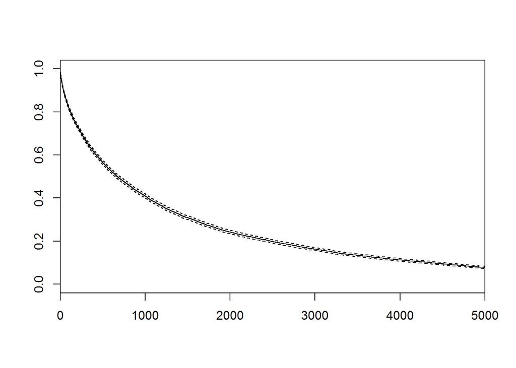

```r
wb_vals <- rweibull(10000, shape=0.653, scale=1190)
plot(survfit(Surv(wb_vals, rep(1, 10000)) ~ 1), xlim=c(0, 5000))
```

It produces the same distribution, thereby indicating this function is consistent with rweibull.

## 4.2 With covariates

Let’s use the registry data to obtain an idea of the variance of ages, along with appropriate coefficient values:

```r
mean(registry_data$age)
```

```
## [1] 64.25934
```

```r
sd(registry_data$age)
```

```
## [1] 19.26978
```

That’s a higher standard deviation than I’d expect! I was going to use 10 or 15 years. The mean is as I’d expect.

And a standard weibull fit gives the coefficient estimates *-0.0615* for age, *0.792* for shape, and *59,300* for scale. Note that these distribution parameters are the exponentiated form of them, and so care should be taken when plugging into an equation.

This gives me an idea of what sort of values to be using, although of course the ones I choose will be arbitrary and not related to this dataset, or from any of our current HMRN data.

```r
mod <- flexsurv::flexsurvreg(Surv(stime, status) ~ age, data=registry_data, dist='weibull')
mod
```

```
## Call:
## flexsurv::flexsurvreg(formula = Surv(stime, status) ~ age, data = registry_data,
##     dist = "weibull")
##
## Estimates:
##        data mean  est        L95%       U95%       se         exp(est)
## shape         NA   7.92e-01   7.59e-01   8.26e-01   1.71e-02         NA
## scale         NA   5.93e+04   4.22e+04   8.34e+04   1.03e+04         NA
## age     6.43e+01  -6.15e-02  -6.63e-02  -5.67e-02   2.43e-03   9.40e-01
##        L95%       U95%
## shape         NA         NA
## scale         NA         NA
## age     9.36e-01   9.45e-01
##
## N = 1784,  Events: 1296,  Censored: 488
## Total time at risk: 1631885
## Log-likelihood = -9947.39, df = 3
## AIC = 19900.78
```

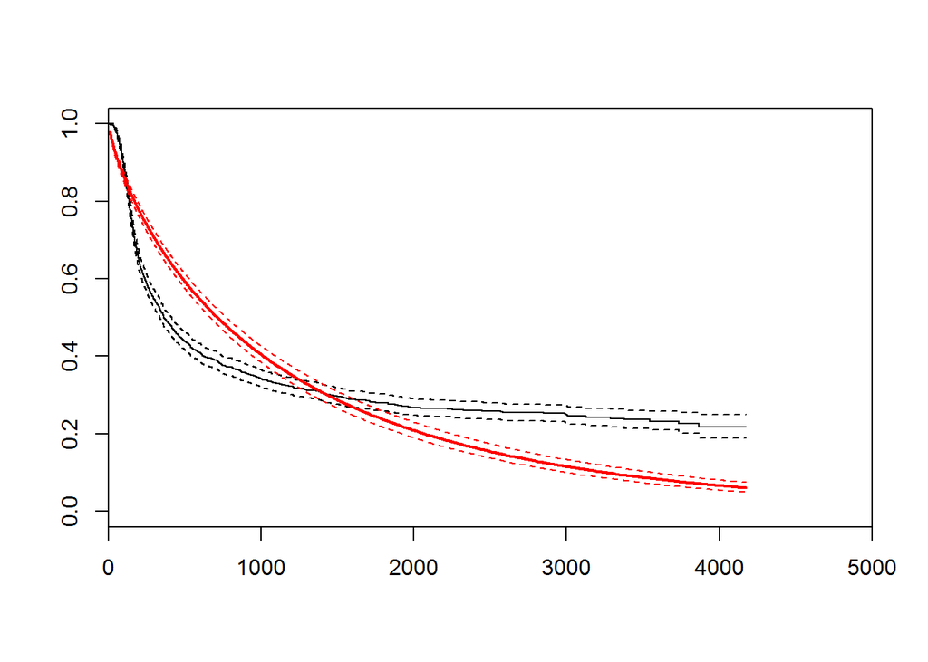

```r
plot(mod, xlim=c(0, 5000))
```

Let’s try using these values to simulate event times which incorporate age.

```r
ageest = weisim2(10000, beta=-0.0615, mu=60, sigma=10, scale=log(59300), shape=0.792, rancens=F, rate=0.5, trunc=F)
```

```
## 0 percent censored
```

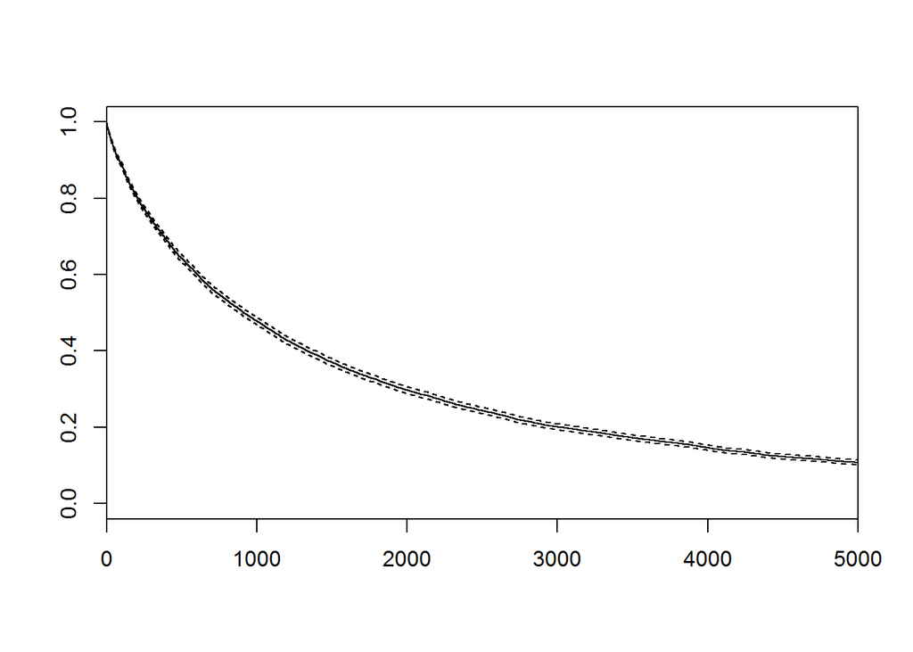

```r
plot(survfit(Surv(time, status) ~ 1, data=ageest), xlim=c(0, 5000))
```

This looks ok, let’s fit a model to it and see what we get.

```r
mod2 <- flexsurvreg(Surv(time, status) ~ x, data=ageest, dist='weibull')
```

```
## Error in (function (formula, data, weights, subset, na.action, dist = "weibull", : Invalid survival times for this distribution
```

```r
mod2
```

```
## Error in eval(expr, envir, enclos): object 'mod2' not found
```

Now let’s try adding in gender, I’ll have a separate column for pbinomials:

Just getting sensible values for sex coefficients:

```r
sex_mod <- flexsurvreg(Surv(stime, status) ~ age + sex, data=registry_data, dist='weibull')
sex_mod
```

```
## Call:
## flexsurvreg(formula = Surv(stime, status) ~ age + sex, data = registry_data,
##     dist = "weibull")
##
## Estimates:
##        data mean  est        L95%       U95%       se         exp(est)
## shape         NA   9.32e-01   8.95e-01   9.71e-01   1.93e-02         NA
## scale         NA   2.79e+05   1.92e+05   4.04e+05   5.27e+04         NA
## age     6.43e+01  -5.44e-02  -5.83e-02  -5.04e-02   2.01e-03   9.47e-01
## sex     8.21e-01  -2.47e+00  -2.73e+00  -2.21e+00   1.31e-01   8.45e-02
##        L95%       U95%
## shape         NA         NA
## scale         NA         NA
## age     9.43e-01   9.51e-01
## sex     6.54e-02   1.09e-01
##
## N = 1784,  Events: 1296,  Censored: 488
## Total time at risk: 1631885
## Log-likelihood = -9609.265, df = 4
## AIC = 19226.53
```

I’ll use the exact same parameters of covariate distributions to try and generate the exact same survival time distribution.

**NB: This high proportion of women isn’t typical of the general population at all!**

```r
table(registry_data$sex)
```

```
##
##    0    1
##  399 1509
```

```r
1509 / (1509 + 399)
```

```
## [1] 0.7908805
```

```r
mean(registry_data$age)
```

```
## [1] 64.25934
```

```r
sd(registry_data$age)
```

```
## [1] 19.26978
```

```r
sextest = weisim2(10000, beta=c(-0.0544, -2.47), mu=64, sigma=19, pbinomial=0.79, scale=log(279000), shape=0.932, rancens=F, rate=0.5, trunc=F)
```

```
## 0 percent censored
```

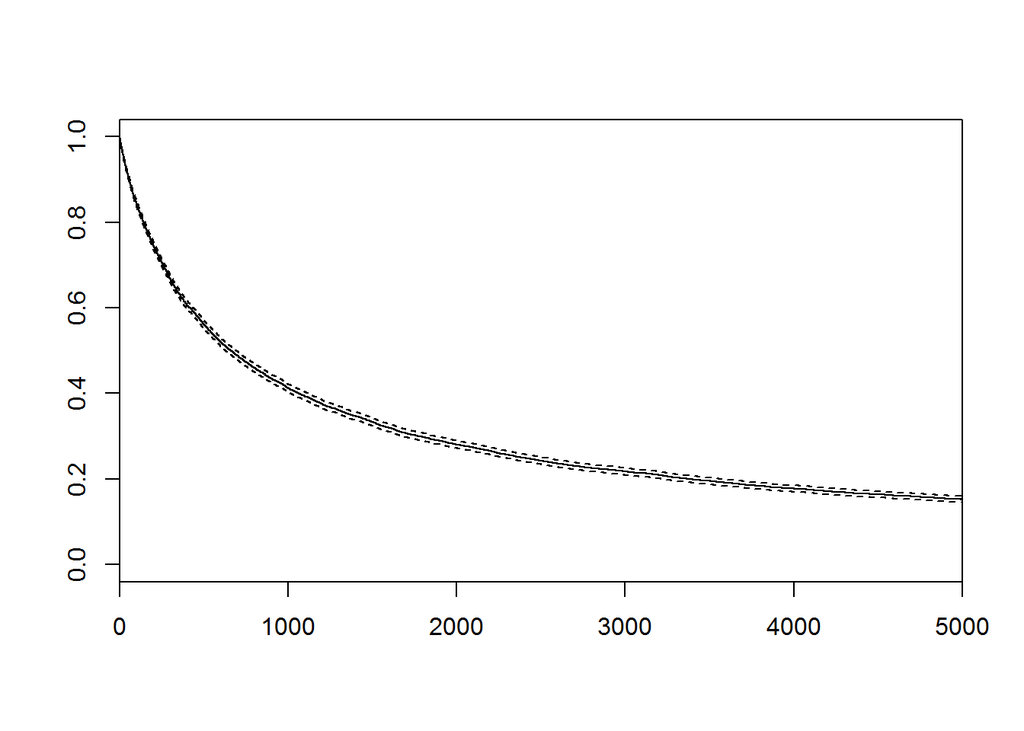

```r
plot(survfit(Surv(time, status) ~ 1, data=sextest), xlim=c(0, 5000))
```

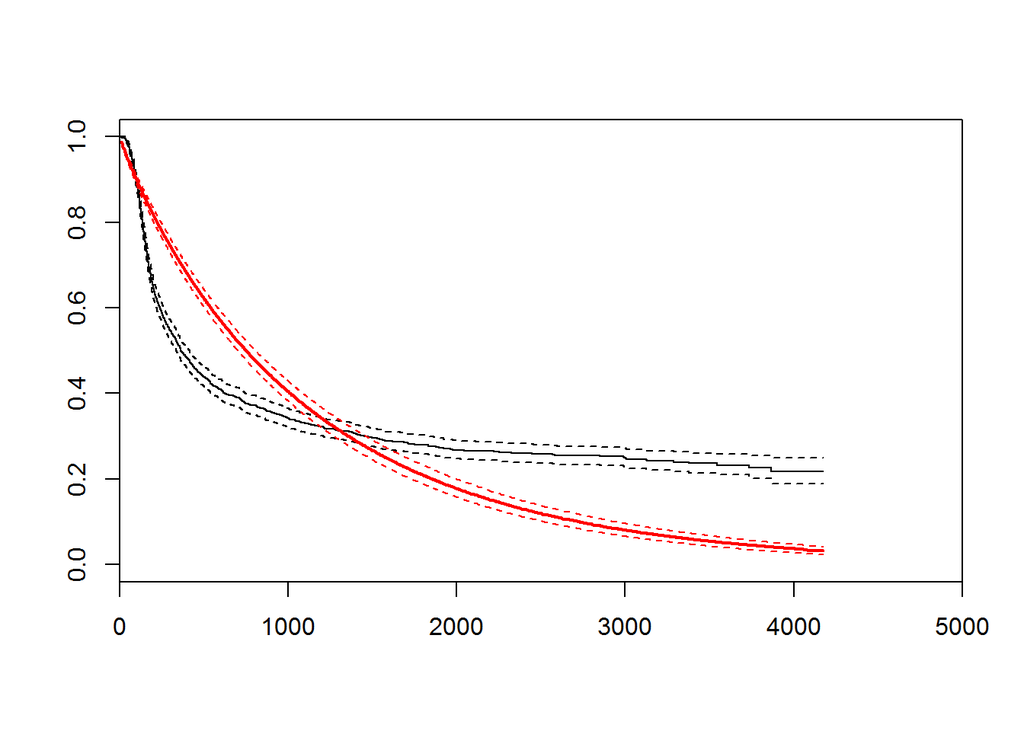

```r
plot(sex_mod, xlim=c(0, 5000))
```

Doesn’t look quite right, does fitting a model to it generate the correct coefficients?

```r
flexsurvreg(Surv(time, status) ~ X1 + X2, data=sextest, dist='weibull')
```

```
## Error in (function (formula, data, weights, subset, na.action, dist = "weibull", : Invalid survival times for this distribution
```

## 4.3 Conclusions

Now I have a function which can generate a dataset with both continuous and binomial covariates, easy. The remaining two issues to solve are:

- Generate censoring patterns
- Simulating registry entry dates

# 5 Simulating entry dates

Now we need to simulate entry dates, assuming that the rate of entry is distributed with a poisson distribution with parameter lambda.

This means that the probability of an incident case at a specific time point can be obtained with the pdf, so the plot below displays the probability of an incident case `x` days after the last incident case:

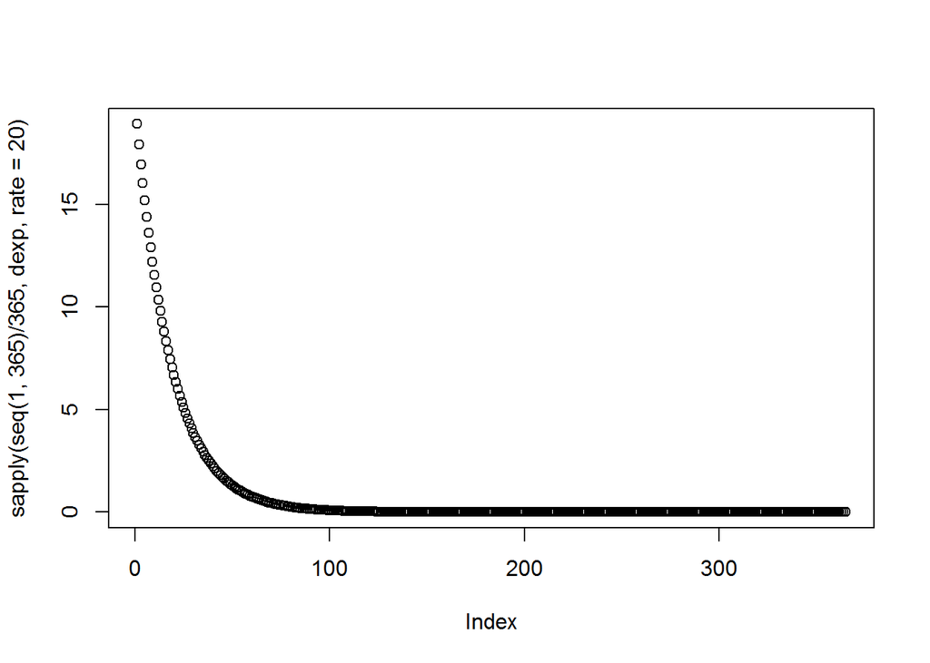

```r
plot(sapply(seq(1, 365) / 365, dexp, rate=20))
```

Likewise the cdf plots the probability that a new event will have occurred `q` days after the previous one. So for a disease with incidence rates of 20 cases a year, generally the longest gap between new cases being incident is 100 days.

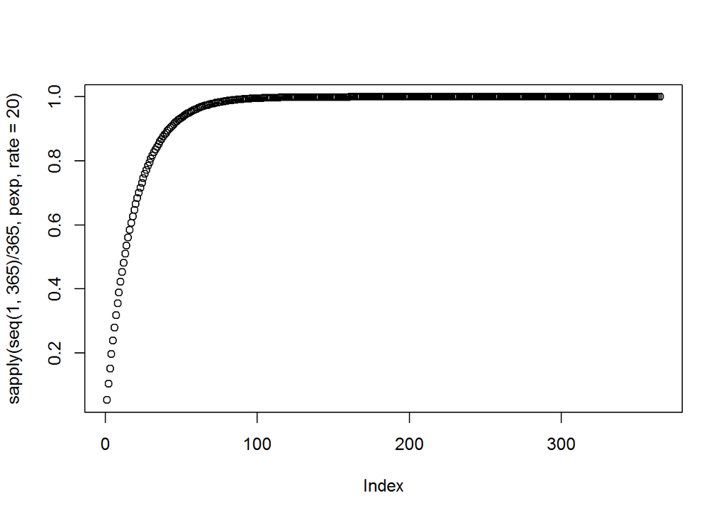

```r
plot(sapply(seq(1, 365) / 365, pexp, rate=20))
```

So drawing from the exponential distribution parameterised by lambda = number of incident cases in a year, and multiplying by 365.25, we can obtain a series of interarrival times.

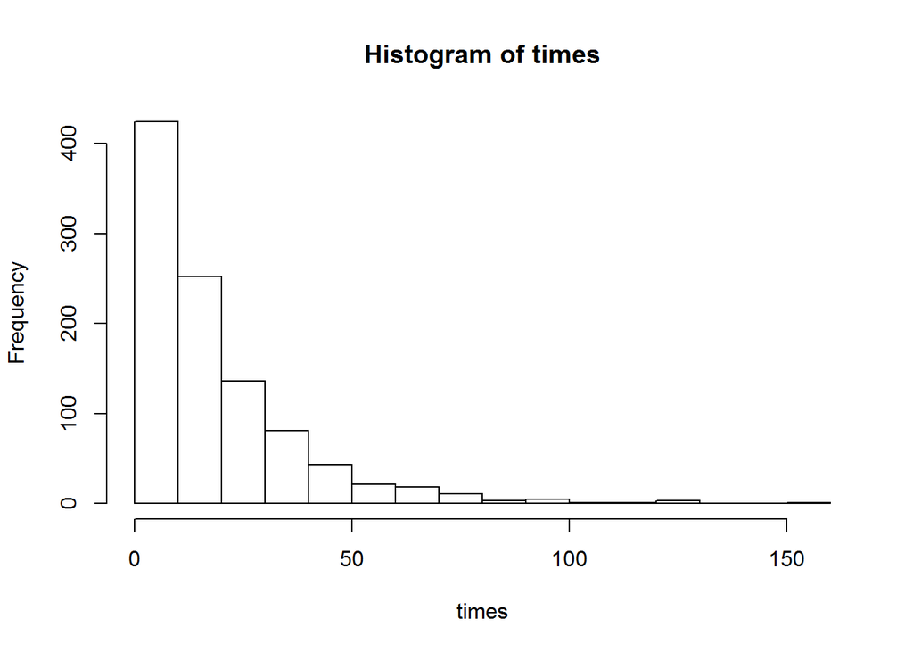

```r
times = round(rexp(1000, 20) * 365.25)
hist(times)
```

By taking the cumulative sum of these we can obtain the number of days since an arbitrary start point.

```r
start_deltas = cumsum(times)
```

And then using `difftime` we can create a function to create actual entry dates by passing in a reference initial date.

```r
sim_entry_dates <- function(n, inc_rate, start_date='2005-01-01') {
    times <- round(rexp(n, inc_rate) * 365.25)
    start_deltas <- cumsum(times)
    sapply(start_deltas, function(x) as.character(as.Date(start_date) + x))
}
```

Let’s test this by asking for 100 cases with an incidence rate of 20 a year, so we’d expect around 5 years of event times.

```r
dates <- sim_entry_dates(100, 20, start_date='2010-03-28')
dates
```

```
##   [1] "2010-04-02" "2010-04-13" "2010-05-01" "2010-05-20" "2010-05-30"
##   [6] "2010-07-04" "2010-07-25" "2010-08-19" "2010-09-06" "2010-10-09"
##  [11] "2010-10-11" "2010-10-18" "2010-12-14" "2011-01-07" "2011-03-02"
##  [16] "2011-03-05" "2011-06-08" "2011-07-03" "2011-07-06" "2011-07-07"
##  [21] "2011-07-11" "2011-07-28" "2011-08-05" "2011-09-14" "2011-09-18"
##  [26] "2011-09-28" "2011-10-25" "2011-12-12" "2011-12-28" "2012-01-28"
##  [31] "2012-02-15" "2012-02-21" "2012-03-01" "2012-03-05" "2012-04-13"
##  [36] "2012-04-14" "2012-04-21" "2012-05-02" "2012-05-03" "2012-05-22"
##  [41] "2012-06-07" "2012-07-02" "2012-07-04" "2012-07-07" "2012-07-25"
##  [46] "2012-07-28" "2012-08-02" "2012-09-05" "2012-09-23" "2012-10-08"
##  [51] "2012-11-20" "2012-12-17" "2012-12-26" "2013-01-19" "2013-01-26"
##  [56] "2013-02-06" "2013-02-11" "2013-02-14" "2013-02-27" "2013-03-24"
##  [61] "2013-04-09" "2013-05-05" "2013-05-07" "2013-05-10" "2013-06-11"
##  [66] "2013-06-15" "2013-08-18" "2013-10-25" "2013-11-12" "2013-12-04"
##  [71] "2013-12-17" "2013-12-27" "2014-01-27" "2014-02-19" "2014-03-07"
##  [76] "2014-04-12" "2014-04-24" "2014-05-21" "2014-05-22" "2014-05-27"
##  [81] "2014-06-05" "2014-06-10" "2014-06-17" "2014-07-11" "2014-07-25"
##  [86] "2014-08-02" "2014-08-14" "2014-08-27" "2014-09-03" "2014-09-16"
##  [91] "2014-10-29" "2014-11-13" "2014-12-30" "2015-01-12" "2015-01-26"
##  [96] "2015-02-13" "2015-02-14" "2015-02-15" "2015-02-24" "2015-03-14"
```

These look good!

## 5.1 Conclusion

So now we can simulate covariates, survival times, and entry dates; event dates can be easily calculated from the survival times and the entry dates. Next we just need censoring to be incorporated.

# 6 Simulating censorship patterns

I’ll be assuming random censoring for this, which requires two steps:

1. Randomly selected a certain proportion of observations to be censored, they can be selected uniformly.
2. Randomly select a censoring time Tc less than survival time Ts. This can be randomly selected from a uniform distribution between the start time and the event time - or would it be more appropriate to have more censoring with people at longer survival times?

At least that’s how I’d do it, whereas the code in `weisim` assumes that time to censor is distributed exponentially, which seems odd to me. The `rate` parameter to this function is the censoring rate, whereby I have no idea how to set a suitable value, so let’s try and fit an exponential model to the censoring data in `registry_data` and get an estimate for a suitable coefficient.

```r
cens_data <- filter(registry_data, status==0)
cens_model <- flexsurvreg(Surv(stime, rep(1, nrow(cens_data))) ~ 1, data=cens_data, dist='exp')
cens_model
```

```
## Call:
## flexsurvreg(formula = Surv(stime, rep(1, nrow(cens_data))) ~
##     1, data = cens_data, dist = "exp")
##
## Estimates:
##       est       L95%      U95%      se
## rate  4.44e-04  4.06e-04  4.85e-04  2.01e-05
##
## N = 488,  Events: 488,  Censored: 0
## Total time at risk: 1099822
## Log-likelihood = -4255.528, df = 1
## AIC = 8513.055
```

So a very small rate then!

As with the weibull distribution, note that the value displayed in this summary is the exponentiated version of the ones displayed in the model summary.

```r
cens_model$coefficients
```

```
## [1] -7.720344
```

```r
exp(cens_model$coefficients)
```

```
## [1] 0.0004437082
```

Let’s just quickly simulate some censoring times to understand which of these values to use.

```r
cens_times1 <- rexp(10000, rate=cens_model$coefficients)
cens_times2 <- rexp(10000, rate=exp(cens_model$coefficients))
```

Oh it has to be the exponentiated version. So the basically the exponentiated values displayed in the summary are **always** the ones we want to use, except in weibull models where `scale` depends on covariates, in which case we need to calculate the exponent of `scale` + betaX.

So let’s try using this value of rate (0.000444) in the `weisim` calculations.

Let’s look at how much censoring is present in the registry data:

```r
table(registry_data$status)
```

```
##
##    0    1
##  612 1296
```

```r
612 / (612+1926) * 100
```

```
## [1] 24.11348
```

Rerunning the following code however, produces vastly different values of censoring, presumably due to the small sample size. The output values look relatively sensible however which is a good thing.

```r
weisim2(10, beta=c(-0.0544, -2.47), mu=64, sigma=19, pbinomial=0.79, scale=log(279000), shape=0.932, rancens=T, rate=0.00044, trunc=F)
```

```
## 30 percent censored
```

```
##    time status       X1 X2
## 1    11      1 56.53286  1
## 2    53      1 59.94010  1
## 3    98      0 71.65164  0
## 4   186      1 83.32060  1
## 5   349      1 87.45183  1
## 6   357      0 46.77684  1
## 7   445      1 35.97248  1
## 8  1365      1 66.19370  1
## 9  1740      0 44.48473  1
## 10 2995      1 68.61693  1
```

I’ll try running it with larger sample sizes repeatedly to see if the censoring proportion is more stable. Yes it is. I could do with a little less censoring but we can work from here.

```r
f = weisim2(10000, beta=c(-0.0544, -2.47), mu=64, sigma=19, pbinomial=0.79, scale=log(279000), shape=0.932, rancens=T, rate=0.00044, trunc=F)
```

```
## 37.34 percent censored
```

```r
f = weisim2(10000, beta=c(-0.0544, -2.47), mu=64, sigma=19, pbinomial=0.79, scale=log(279000), shape=0.932, rancens=T, rate=0.00044, trunc=F)
```

```
## 38.22 percent censored
```

```r
f = weisim2(10000, beta=c(-0.0544, -2.47), mu=64, sigma=19, pbinomial=0.79, scale=log(279000), shape=0.932, rancens=T, rate=0.00044, trunc=F)
```

```
## 37.23 percent censored
```

```r
f = weisim2(10000, beta=c(-0.0544, -2.47), mu=64, sigma=19, pbinomial=0.79, scale=log(279000), shape=0.932, rancens=T, rate=0.00044, trunc=F)
```

```
## 37.45 percent censored
```

# 7 Combining survival times and entry dates

Now I’ll create a function to wrap both of these steps into a one line call to create a simulated dataset.

```r
simulate_dataset <- function(n=100, inc_rate=50, scale=1, shape=1, beta=NULL, mu=NULL, sigma=NULL,
                             pbinomial=NULL, rancens=T, censrate=1, start_date='2005-01-01') {
    entry_dates <- sim_entry_dates(n, inc_rate=inc_rate, start_date=start_date)
    df <- weisim2(n, beta=beta, mu=mu, sigma=sigma, pbinomial=pbinomial, scale=scale, shape=shape, rancens=rancens, rate=censrate, trunc=F)

    # Clean up data by calculating event dates and converting binary predictors to factors
    df$entry <- entry_dates
    df$eventdate <- as.character(as.Date(df$entry) + df$time)
    binom_columns <- sapply(seq_along(pbinomial), function(i) paste('X', i+length(mu), sep=''))
    df[, binom_columns] <- as.factor(df[, binom_columns])

    df
}
```

Now let’s try running this with sensible parameters that I’ve established from the registry_data dataset.

```r
sim_data = simulate_dataset(10000, inc_rate=30, beta=c(-0.0544, -2.47), mu=64, sigma=19, pbinomial=0.79, scale=log(279000), shape=0.932,
                            rancens=T, censrate=0.00044)
```

```
## 36.79 percent censored
```

```r
summary(sim_data)
```

```
##       time             status             X1           X2
##  Min.   :    0.0   Min.   :0.0000   Min.   :  0.3583   0:2066
##  1st Qu.:  142.0   1st Qu.:0.0000   1st Qu.: 51.2712   1:7934
##  Median :  424.0   Median :1.0000   Median : 64.1118
##  Mean   :  843.6   Mean   :0.6321   Mean   : 64.0296
##  3rd Qu.: 1067.2   3rd Qu.:1.0000   3rd Qu.: 76.8740
##  Max.   :15800.0   Max.   :1.0000   Max.   :153.3408
##     entry            eventdate
##  Length:10000       Length:10000
##  Class :character   Class :character
##  Mode  :character   Mode  :character
##
##
##
```

```r
min(sim_data$entry)
```

```
## [1] "2005-01-08"
```

```r
max(sim_data$entry)
```

```
## [1] "2332-01-10"
```

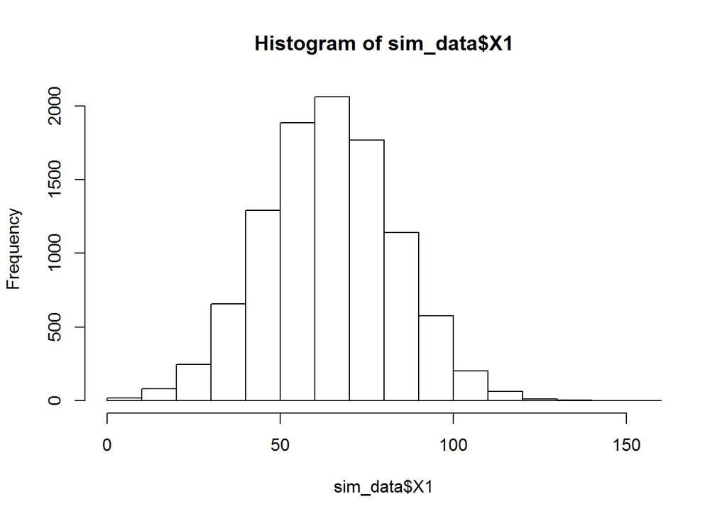

```r
hist(sim_data$X1)
```

Maybe a better way would be to:

- Determine the sample size required (<= 1000)
- Infer from this a sensible incidence rate
- Calculate multiple datasets, ordered by survival time
- Take the average to hopefully even out any extreme values

Is bootstrapping this overkill?! I’ll firstly come up with a simulated dataset with sensible parameter values and see how it does.

## 7.1 Sensible parameters

I’ll want a thousand or two patients, let’s go with a thousand. Say I want a 10 year repository, so 100 incident cases a year. I’ll make age have a standard deviation of 10, with a mean of 65, so that most cases are in 45-85 which makes sense. For sex I’ll use a probability of 0.55, as females will be more likely to have this simulated disease.

I’ll use trial and error to get a value of censrate that provides around 30% censoring.

```r
sens_sim_data = simulate_dataset(1000, inc_rate=100, beta=c(-0.0544, -2.47), mu=65, sigma=10, pbinomial=0.55, scale=log(279000), shape=0.932,
                            rancens=T, censrate=0.00014)
```

```
## 28.7 percent censored
```

```r
summary(sens_sim_data)
```

```
##       time             status            X1         X2
##  Min.   :    0.0   Min.   :0.000   Min.   : 32.91   0:454
##  1st Qu.:  268.5   1st Qu.:0.000   1st Qu.: 58.36   1:546
##  Median :  854.0   Median :1.000   Median : 65.05
##  Mean   : 1938.3   Mean   :0.713   Mean   : 65.11
##  3rd Qu.: 2504.2   3rd Qu.:1.000   3rd Qu.: 72.12
##  Max.   :23299.0   Max.   :1.000   Max.   :100.39
##     entry            eventdate
##  Length:1000        Length:1000
##  Class :character   Class :character
##  Mode  :character   Mode  :character
##
##
##
```

```r
min(sens_sim_data$entry)
```

```
## [1] "2005-01-08"
```

```r
max(sens_sim_data$entry)
```

```
## [1] "2014-10-23"
```

```r
min(sens_sim_data$eventdate)
```

```
## [1] "2005-01-08"
```

```r
max(sens_sim_data$eventdate)
```

```
## [1] "2078-08-07"
```

Age looks sensible

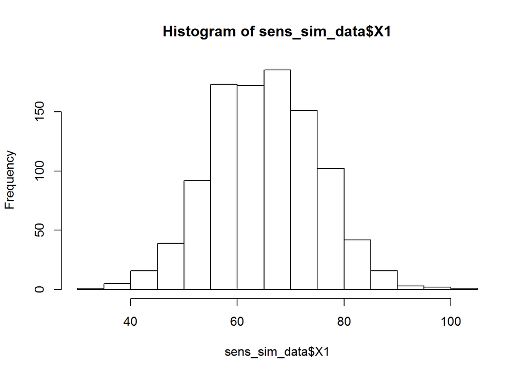

```r
hist(sens_sim_data$X1)
```

Some very long survivals, 25,000 days is 68 years! These particularly don’t make sense as the age of these persons at diagnosis was 50, so they’re going to live to be 120!

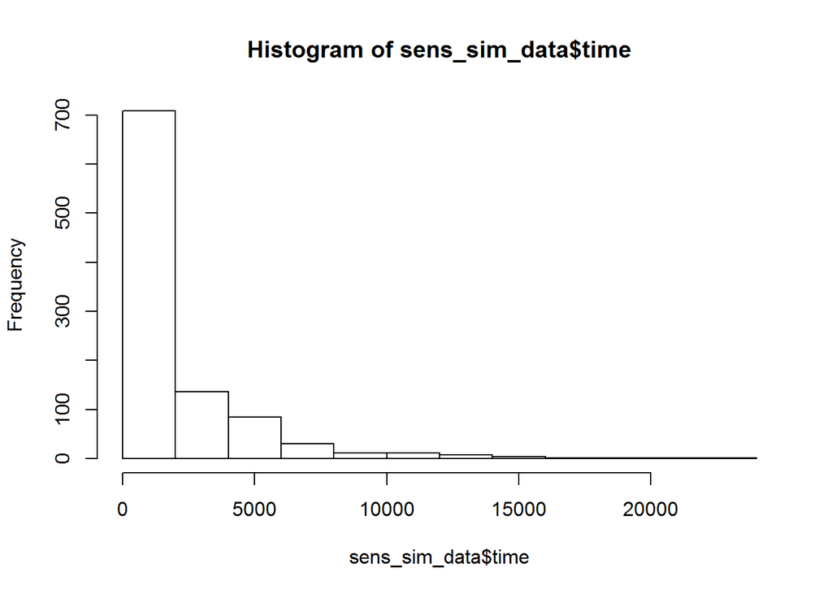

```r
hist(sens_sim_data$time)
```

```r
sens_sim_data[sens_sim_data$time > 20000, ]
```

```
##       time status       X1 X2      entry  eventdate
## 999  20816      0 58.88526  0 2014-10-14 2071-10-11
## 1000 23299      0 52.99541  0 2014-10-23 2078-08-07
```

So most patients are dead by 27 years, but this is too long! I’ll play with the scale parameter until I can get this to more reasonable values.

```r
plot(flexsurvreg(Surv(time, status) ~ X1 + X2, data=sens_sim_data, dist='weibull'))
```

```
## Error in (function (formula, data, weights, subset, na.action, dist = "weibull", : Invalid survival times for this distribution
```

## 7.2 Sensible survival times

I’ve just realised that I’ll need to censor the dataset if people are still alive at a set point (index date?), which in the `registry_data` dataset appeasr to be spread out over several days in December.

```r
registry_data %>%
    filter(!is.na(EventDate)) %>%
    arrange(EventDate) %>%
    tail(30)
```

```
##        ID sex      age DateOfDiag status  EventDate stime status2
## 1755  670   0 13.55510 2011-08-08      0 2015-12-24  1599       0
## 1756 1713   1 14.35797 2007-12-11      0 2015-12-24  2935       0
## 1757 1036   0 15.29842 2011-09-29      0 2015-12-24  1547       0
## 1758  554   0 19.83367 2009-12-31      0 2015-12-24  2184       0
## 1759  149   1 31.16427 2006-11-04      0 2015-12-24  3337       0
## 1760 1282   1 41.21218 2013-02-09      0 2015-12-24  1048       0
## 1761 1317   1 47.84120 2004-12-11      0 2015-12-24  4030       0
## 1762 1177   0 59.00890 2011-04-28      0 2015-12-24  1701       0
## 1763  145   0 68.02327 2009-08-01      0 2015-12-24  2336       0
## 1764 1815   0 77.11225 2012-07-22      0 2015-12-24  1250       0
## 1765  911   0 82.67693 2007-11-04      0 2015-12-24  2972       0
## 1766 1220   1 37.31964 2007-02-26      0 2015-12-25  3224       0
## 1767 1205   1 41.64203 2005-05-14      0 2015-12-25  3877       0
## 1768 1219   0 48.20808 2011-06-08      0 2015-12-25  1661       0
```

[output cut: 16 more lines]

Since I’m going for 10 years of data, I’ll have it censored beyond 2015-03-17. This will then need to recalculate the survival times.

```r
simulate_dataset2 <- function(n=100, inc_rate=50, scale=1, shape=1, beta=NULL, mu=NULL, sigma=NULL,
                             pbinomial=NULL, rancens=T, censrate=1, start_date='2005-01-01',
                             index='2015-03-17') {

    entry_dates <- sim_entry_dates(n, inc_rate=inc_rate, start_date=start_date)
    df <- weisim2(n, beta=beta, mu=mu, sigma=sigma, pbinomial=pbinomial, scale=scale, shape=shape, rancens=rancens, rate=censrate, trunc=F)

    # Clean up data by calculating event date and censoring those beyond index
    df$entry <- entry_dates
    df$eventdate <- as.character(as.Date(df$entry) + df$time)
    cens_at_index <- df$eventdate > index
    df$eventdate[cens_at_index] <- index
    df$status[cens_at_index] <- 0
    df$time[cens_at_index] <- difftime(as.Date(df$eventdate[cens_at_index]), as.Date(df$entry[cens_at_index]), units='days')

    # convert binary predictors to factors
    binom_columns <- sapply(seq_along(pbinomial), function(i) paste('X', i+length(mu), sep=''))
    df[, binom_columns] <- as.factor(df[, binom_columns])

    df
}
```

Let’s try this now:

```r
sens_sim_data2 = simulate_dataset2(1000, inc_rate=100, beta=c(-0.05, -2), mu=65, sigma=10, pbinomial=0.55, scale=log(27900), shape=0.8,
                                  rancens=T, censrate=0.00014, start_date='2003-01-01', index='2015-03-17')
```

```
## 7.6 percent censored
```

```r
summary(sens_sim_data2)
```

```
##       time            status            X1        X2
##  Min.   :   0.0   Min.   :0.000   Min.   :32.21   0:453
##  1st Qu.:  57.0   1st Qu.:1.000   1st Qu.:58.19   1:547
##  Median : 181.0   Median :1.000   Median :64.44
##  Mean   : 341.3   Mean   :0.818   Mean   :64.88
##  3rd Qu.: 551.5   3rd Qu.:1.000   3rd Qu.:71.37
##  Max.   :1246.0   Max.   :1.000   Max.   :93.99
##     entry            eventdate
##  Length:1000        Length:1000
##  Class :character   Class :character
##  Mode  :character   Mode  :character
##
##
##
```

```r
min(sens_sim_data2$entry)
```

```
## [1] "2003-01-03"
```

```r
max(sens_sim_data2$entry)
```

```
## [1] "2013-03-19"
```

```r
min(sens_sim_data2$eventdate)
```

```
## [1] "2003-01-03"
```

```r
max(sens_sim_data2$eventdate)
```

```
## [1] "2015-03-17"
```

Note that I’m using an index date around 12 years after the start date, while I’m asking for effectively 10 years of incidence (100 cases a year, with 1000 patients), so that I shouldn’t have any issues with patients being entered before the index date.

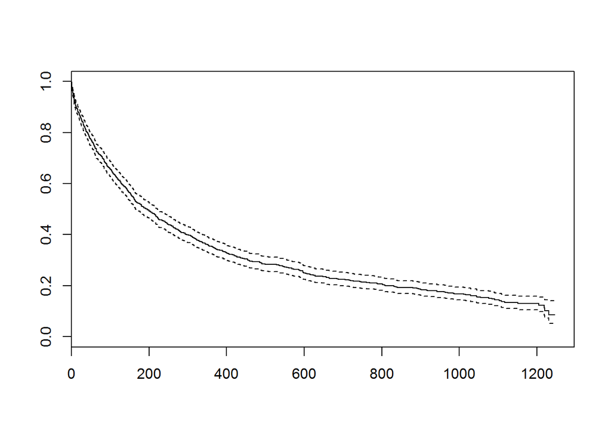

```r
plot(survfit(Surv(time, status) ~ 1, data=sens_sim_data2))
```

# 8 Final Tuning

Now let’s tie all these functions into one place and see if I can generate a sensible dataset!

```r
rm(list = ls())
```

```r
my_weisim <- function(n=100, beta=NULL, mu=NULL, sigma=NULL, pbinomial=NULL, scale=1, shape=1, rancens=T, rate=1, trunc=F, tau=2) {
    if (! length(mu) == length(sigma))
        stop("Error: mu and sigma must have the same length.")

    if (! length(beta) == length(mu) + length(pbinomial))
        stop("Error: Number of betas must be equal to length of mu + pbinomial")

    # Always have intercept, which is just scale if no other covariates are supplied
    x = cbind(rep(1, n))
    # Add continuous variables
    if (!is.null(mu) & !is.null(sigma))
        x = cbind(x, mapply(function(m, s) rnorm(n, m, s), mu, sigma))
    # Add binary variables
    if (!is.null(pbinomial))
        x = cbind(x, sapply(pbinomial, function(p) rbinom(n, 1, p)))

    bx = x %*% c(scale, beta)

    t = (-log(runif(n))) ^ (1/shape) * exp(bx)  # This is rweibull
    ic = rep(1, n)
    if (rancens == T) {
        c1 = (-log(runif(n))/rate)  # This is rexp
        i = c1 < t
        t[i] = c1[i]
        ic[i] = 0
    }
    if (trunc == T) {
        i = t > tau
        t[i] = tau
        ic[i] = 0
    }
    time = round(t)
    time = ifelse(time == 0, 1, time)
    cens = ic
    x = x[, -1]
    cat(100 * sum(1-cens) / n, "percent censored\n")
    data.frame(time=time, status=cens, x)
}
```

```r
sim_entry_dates <- function(n, inc_rate, start_date='2005-01-01') {
    times <- round(rexp(n, inc_rate) * 365.25)
    start_deltas <- cumsum(times)
    sapply(start_deltas, function(x) as.character(as.Date(start_date) + x))
}
```

```r
simulate_dataset <- function(n=100, inc_rate=50, scale=1, shape=1, beta=NULL, mu=NULL, sigma=NULL,
                             pbinomial=NULL, rancens=T, censrate=1, start_date='2005-01-01',
                             index='2015-03-17') {

    entry_dates <- sim_entry_dates(n, inc_rate=inc_rate, start_date=start_date)
    df <- my_weisim(n, beta=beta, mu=mu, sigma=sigma, pbinomial=pbinomial, scale=scale, shape=shape, rancens=rancens, rate=censrate, trunc=F)

    # Clean up data by calculating event date and censoring those beyond index
    df$entry <- entry_dates
    df$eventdate <- as.character(as.Date(df$entry) + df$time)
    cens_at_index <- df$eventdate > index
    df$eventdate[cens_at_index] <- index
    df$status[cens_at_index] <- 0
    df$time[cens_at_index] <- difftime(as.Date(df$eventdate[cens_at_index]), as.Date(df$entry[cens_at_index]), units='days')

    # convert binary predictors to factors
    binom_columns <- sapply(seq_along(pbinomial), function(i) paste('X', i+length(mu), sep=''))
    df[, binom_columns] <- as.factor(df[, binom_columns])

    df
}
```

```r
set.seed(17)
df <- simulate_dataset(1000, inc_rate=100, scale=11.2, shape=0.5, mu=65, sigma=10, pbinomial=0.51, beta=c(-0.05, 0.4),
                       rancens=T, censrate=0.0001, start_date='2003-01-01', index='2015-03-17')
```

```
## 27.8 percent censored
```

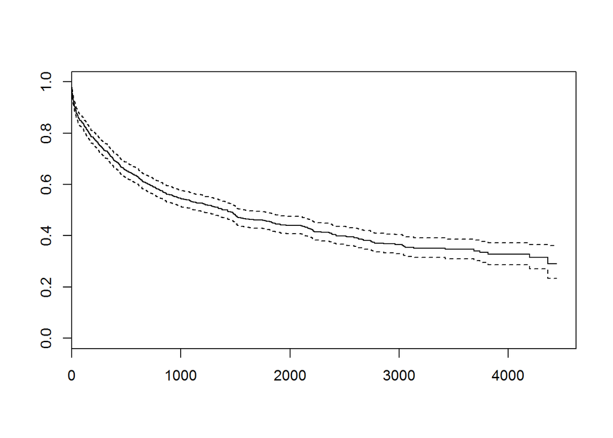

```r
plot(survfit(Surv(time, status) ~ 1, data=df))
```

```r
flexsurvreg(Surv(time+1, status) ~ X1 + X2, data=df, dist='weibull')
```

```
## Call:
## flexsurvreg(formula = Surv(time + 1, status) ~ X1 + X2, data = df,
##     dist = "weibull")
##
## Estimates:
##        data mean  est        L95%       U95%       se         exp(est)
## shape         NA   5.33e-01   4.96e-01   5.73e-01   1.98e-02         NA
## scale         NA   4.33e+04   1.45e+04   1.29e+05   2.41e+04         NA
## X1      6.49e+01  -4.50e-02  -6.12e-02  -2.89e-02   8.24e-03   9.56e-01
## X21     4.92e-01   4.07e-01   9.34e-02   7.20e-01   1.60e-01   1.50e+00
##        L95%       U95%
## shape         NA         NA
## scale         NA         NA
## X1      9.41e-01   9.72e-01
## X21     1.10e+00   2.06e+00
##
## N = 1000,  Events: 558,  Censored: 442
## Total time at risk: 1236976
## Log-likelihood = -4645.564, df = 4
## AIC = 9299.129
```

This dataset looks good, with a cure time looking around 3 years when deaths start to tail off. Both sex and age are statistically significant predictors, but this can be changed if desired. The survival curve looks like one from a real data set, it’s just the betas I’m not so sure about.

# 9 Descriptive stats of simulated dataset

## 9.1 Survival time

A large proportion of people have events in the first 100 days, I’ll check whether these are deaths or censorings later on. It appears to indicate that this simulated disease behaves quite similarly to AML, with a fast acting progression leading to a high initial number of deaths.

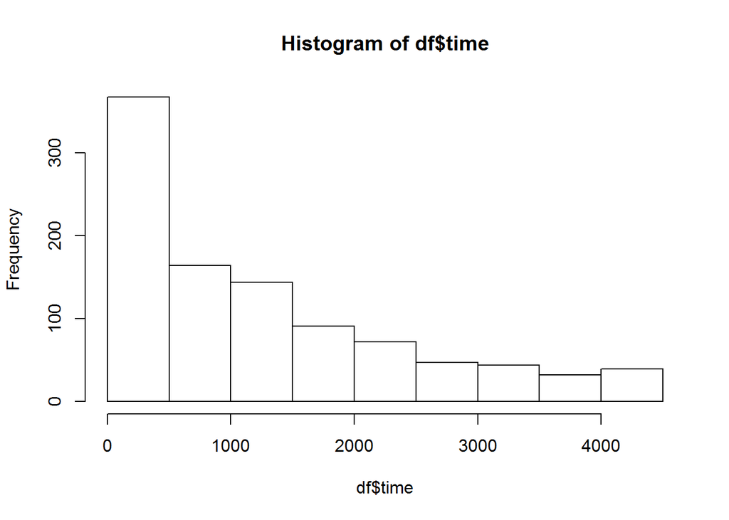

```r
hist(df$time)
```

Below is the histogram of the survival times from just the people who had an event, it follows the plot of all patients above, showing that the disease acts very quickly (within one hundred days) and also shows that the censoring appears to be random.

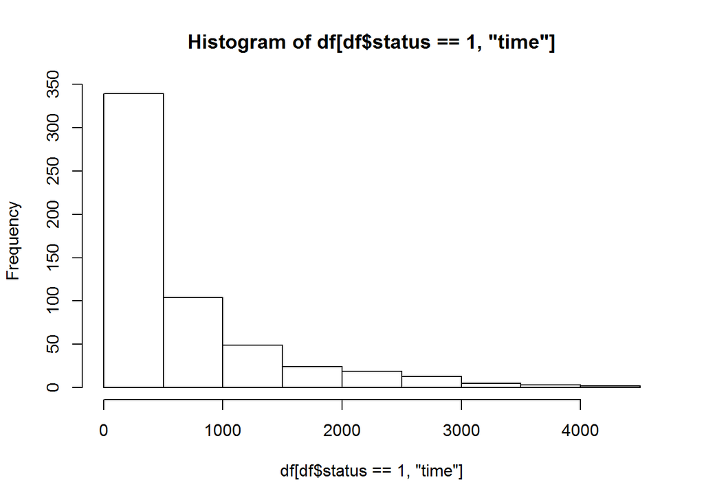

```r
hist(df[df$status==1, 'time'])
```

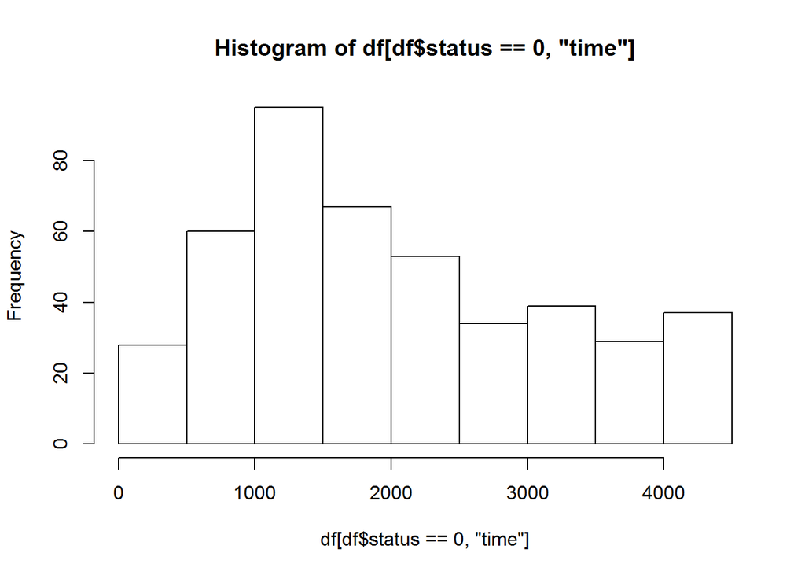

```r
hist(df[df$status==0, 'time'])
```

## 9.2 Age

Perhaps this simulated age is **too** normal, maybe should have added some noise to age?

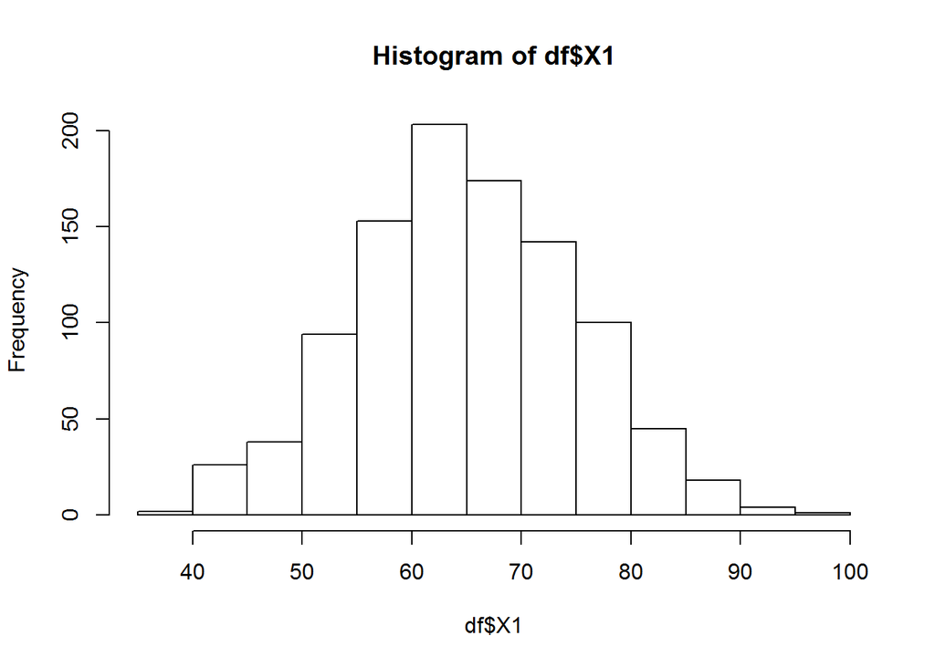

```r
hist(df$X1)
```

The univariate model below shows a slight statistically significant impact of age on hazard, this is the direction I was wanting so that’s good.

```r
coxph(Surv(time, status) ~ X1, data=df)
```

```
## Call:
## coxph(formula = Surv(time, status) ~ X1, data = df)
##
##       coef exp(coef) se(coef)    z       p
## X1 0.02316   1.02343  0.00434 5.34 9.4e-08
##
## Likelihood ratio test=28.5  on 1 df, p=9.31e-08
## n= 1000, number of events= 558
```

## 9.3 Sex

Note that sex doesn’t come with any encoded labels, I provided the probability 0.51 which I thought would be the probability of a value = 1, which in this case I was going to use to mean female. However, the proportion of 1s in this dataset is 0.492, indicating that either female has actually been encoded as 0, or that females are encoded as 1 but have just been selected as a minority due to chance.

**Having confirmed that the simulate dataset code is working as intended, then males are encoded as 0 and females as 1 in the sex covariate**

```r
table(df$X2)
```

```
##
##   0   1
## 508 492
```

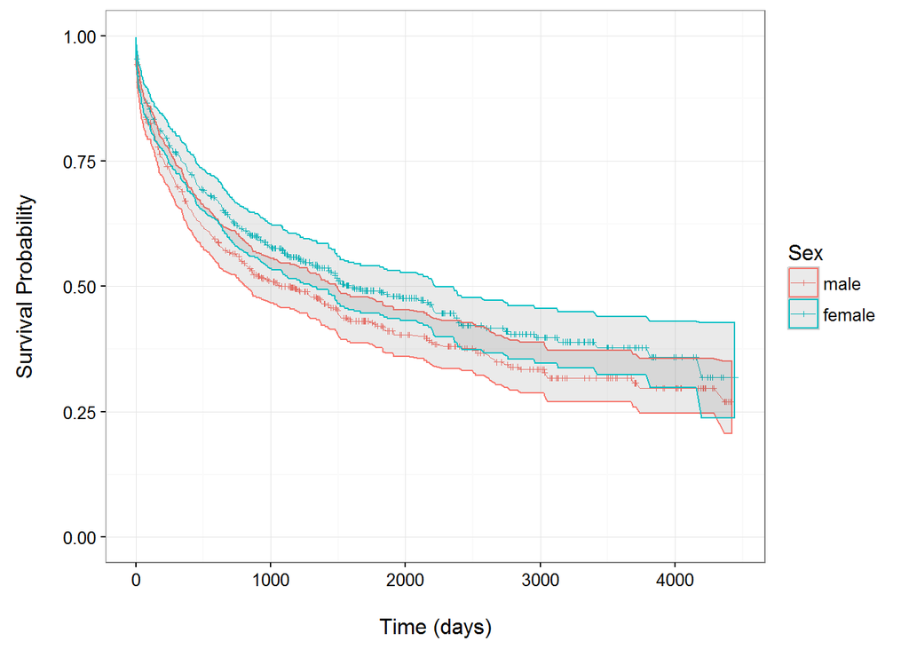

```r
survf <- survfit(Surv(time, status) ~ X2, data=df)
plotdf <- data.frame(surv=survf$surv, cens=survf$n.censor, time=survf$time, upper=survf$upper, lower=survf$lower, sex=rep(c(0, 1), survf$strata))
ggplot(plotdf, aes(x=time, y=surv, colour=as.factor(sex))) +
    geom_line(size=0.1) +
    geom_point(data=subset(plotdf, cens>=1), aes(x=time, y=surv), shape=3, size=0.7) +
    geom_ribbon(aes(ymin=lower, ymax=upper), alpha=0.1) +
    ylim(0,1) +
    labs(x='\nTime (days)', y='Survival Probability\n') +
    scale_colour_discrete('Sex', breaks=c(0, 1), labels=c('male', 'female')) +
    theme_bw()
```

```r
coxph(Surv(time, status) ~ X2, data=df)
```

```
## Call:
## coxph(formula = Surv(time, status) ~ X2, data = df)
##
##       coef exp(coef) se(coef)    z     p
## X21 -0.195     0.823    0.085 -2.3 0.022
##
## Likelihood ratio test=5.29  on 1 df, p=0.0214
## n= 1000, number of events= 558
```

```r
with(df, table(X2, status))
```

```
##    status
## X2    0   1
##   0 207 301
##   1 235 257
```

I’ll just save this dataset then for future use, along with renaming covariate columns.

```r
prevsim <- dplyr::select(df, time, status, age=X1, sex=X2, entrydate=entry, eventdate)
save(prevsim, file='data/prevsim.rda')
```

# 10 Potential issues

- Is the effect of sex too strong?
- Why are there two peaks in the survival times of censored patients?
- Should there be noise added to age and sex, to reduce the statistical significance of the betas?